# Text clustering

# Evaluation & model comparison

|  | model | n_clusters | sil | dbi | ari | chi | nmi | vmeasure | fmi | aic | bic |
| --- | --- | --- | --- | --- | --- | --- | --- | --- | --- | --- | --- |
| 0 | NMF | 2 | 0.004533 | 0.509409 | 0.180296 | 14251.323153 | 0.141601 | 0.141601 | 0.597749 | NaN | NaN |
| 1 | NMF | 3 | 0.003187 | 0.742759 | 0.115184 | 5586.882664 | 0.133096 | 0.133096 | 0.491241 | NaN | NaN |
| 2 | NMF | 4 | 0.003195 | 0.916913 | 0.069661 | 3045.386125 | 0.091819 | 0.091819 | 0.407219 | NaN | NaN |
| 3 | NMF | 5 | 0.003267 | 0.979509 | 0.061506 | 2186.468128 | 0.083151 | 0.083151 | 0.376629 | NaN | NaN |
| 4 | NMF | 6 | 0.003837 | 0.984584 | 0.057794 | 1783.782566 | 0.079281 | 0.079281 | 0.360830 | NaN | NaN |
| 5 | NMF | 7 | 0.004154 | 1.050220 | 0.048855 | 1386.168843 | 0.073076 | 0.073076 | 0.328803 | NaN | NaN |
| 6 | NMF | 8 | 0.004699 | 1.066833 | 0.046928 | 1185.550037 | 0.070533 | 0.070533 | 0.315233 | NaN | NaN |
| 7 | NMF | 9 | 0.004908 | 1.122024 | 0.039335 | 996.872062 | 0.066406 | 0.066406 | 0.295301 | NaN | NaN |
| 8 | NMF | 10 | 0.005077 | 1.182225 | 0.036013 | 814.212042 | 0.063048 | 0.063048 | 0.275793 | NaN | NaN |
| 9 | LDA | 2 | 0.011603 | 0.439465 | 0.141208 | 19526.019270 | 0.109482 | 0.109482 | 0.576084 | NaN | NaN |
| 10 | LDA | 3 | 0.009076 | 0.661262 | 0.105144 | 7012.369149 | 0.087896 | 0.087896 | 0.505058 | NaN | NaN |
| 11 | LDA | 4 | 0.008764 | 0.747129 | 0.100390 | 3977.938616 | 0.083175 | 0.083175 | 0.479955 | NaN | NaN |
| 12 | LDA | 5 | 0.002641 | 0.851844 | 0.077192 | 2576.330906 | 0.080452 | 0.080452 | 0.411790 | NaN | NaN |
| 13 | LDA | 6 | 0.002650 | 0.894177 | 0.054668 | 1872.198037 | 0.069811 | 0.069811 | 0.386521 | NaN | NaN |
| 14 | LDA | 7 | 0.001270 | 0.951479 | 0.084714 | 1563.482645 | 0.089956 | 0.089956 | 0.387788 | NaN | NaN |
| 15 | LDA | 8 | 0.000668 | 1.007908 | 0.054849 | 1264.166591 | 0.083923 | 0.083923 | 0.339010 | NaN | NaN |
| 16 | LDA | 9 | 0.000787 | 0.999715 | 0.048902 | 1084.228109 | 0.078780 | 0.078780 | 0.333638 | NaN | NaN |
| 17 | LDA | 10 | 0.000586 | 0.999675 | 0.059373 | 975.351021 | 0.076078 | 0.076078 | 0.351000 | NaN | NaN |
| 18 | VKM | 2 | 0.014870 | 8.040852 | 0.107680 | 70.131682 | 0.089734 | 0.089734 | 0.573407 | NaN | NaN |
| 19 | VKM | 3 | 0.006019 | 8.039698 | 0.068761 | 53.784207 | 0.097995 | 0.097995 | 0.497456 | NaN | NaN |
| 20 | VKM | 4 | 0.010165 | 7.289754 | 0.087354 | 47.110517 | 0.101048 | 0.101048 | 0.471397 | NaN | NaN |
| 21 | VKM | 5 | 0.011305 | 6.861151 | 0.069837 | 42.976392 | 0.085985 | 0.085985 | 0.439425 | NaN | NaN |
| 22 | VKM | 6 | 0.009436 | 6.733998 | 0.045513 | 39.970086 | 0.082517 | 0.082517 | 0.391212 | NaN | NaN |
| 23 | VKM | 7 | 0.013185 | 6.291700 | 0.045108 | 39.158727 | 0.078359 | 0.078359 | 0.381239 | NaN | NaN |
| 24 | VKM | 8 | 0.013640 | 6.259618 | 0.041643 | 36.705878 | 0.083795 | 0.083795 | 0.361781 | NaN | NaN |
| 25 | VKM | 9 | 0.016493 | 6.177144 | 0.025482 | 35.419484 | 0.054393 | 0.054393 | 0.329614 | NaN | NaN |
| 26 | VKM | 10 | 0.016365 | 5.824494 | 0.037494 | 33.752177 | 0.074603 | 0.074603 | 0.338403 | NaN | NaN |
| 27 | GMM | 2 | 0.017452 | 10.094020 | 0.134369 | 47.318841 | 0.099409 | 0.099409 | 0.567125 | -4.086707e+06 | -3.822102e+06 |
| 28 | GMM | 3 | 0.016710 | 8.133522 | 0.133379 | 40.755002 | 0.093637 | 0.093637 | 0.550997 | -4.110152e+06 | -3.713242e+06 |
| 29 | GMM | 4 | 0.014783 | 8.612889 | 0.108520 | 36.963024 | 0.089609 | 0.089609 | 0.465583 | -4.148947e+06 | -3.619732e+06 |
| 30 | GMM | 5 | 0.012072 | 8.283369 | 0.062351 | 35.634838 | 0.089582 | 0.089582 | 0.402150 | -4.137536e+06 | -3.476015e+06 |
| 31 | GMM | 6 | 0.013959 | 7.347594 | 0.053545 | 36.125310 | 0.079824 | 0.079824 | 0.374835 | -4.151446e+06 | -3.357619e+06 |
| 32 | GMM | 7 | 0.015136 | 7.026127 | 0.039893 | 34.959005 | 0.066883 | 0.066883 | 0.350356 | -4.149040e+06 | -3.222908e+06 |
| 33 | GMM | 8 | 0.014642 | 6.920430 | 0.042998 | 33.819348 | 0.075688 | 0.075688 | 0.323288 | -4.113009e+06 | -3.054571e+06 |
| 34 | GMM | 9 | 0.014064 | 6.767504 | 0.029793 | 30.800888 | 0.060429 | 0.060429 | 0.300879 | -4.079594e+06 | -2.888851e+06 |
| 35 | GMM | 10 | 0.019556 | 6.178445 | 0.047591 | 32.257755 | 0.078540 | 0.078540 | 0.333080 | -4.171430e+06 | -2.848381e+06 |

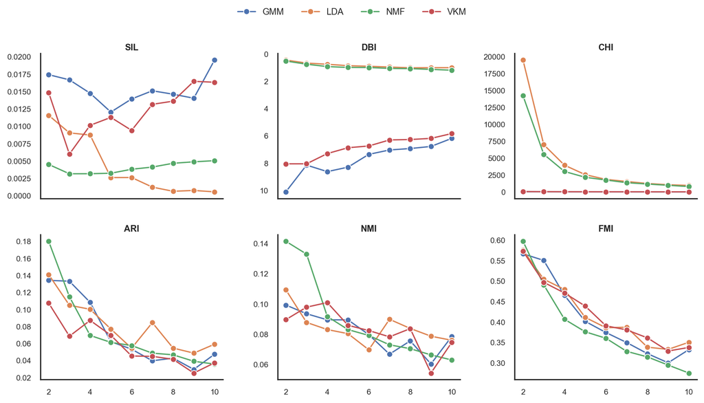

```python
# get indicators
comparisons = Clusters_Indicators(cleaned,models=test_models,ml_dct=dct_models)
comparisons10 = Clusters_Indicators(cleaned,models=test_models,ml_dct=dct_models,labels10=True)
clear_output()
display(comparisons)
comparison_charts(comparisons)
if not qmd:
    comparisons.to_csv(f'outputs/Indicators_Comparison_svd.csv')
```

Here above we can see the results of the various models on some measurement scales. We graphed the most important ones. We decided to train the models from k2 all the way to k10 so we can see a gradual overview of what happens when increasing the k. We decided to not only include k5 and k10 but also k2. We did this because the dataset includes sentiment labels of 0 and 1 and we wanted to see if the models would cluster the reviews in the same groups as the sentiments. While the models dont explicitly know the sentiment scores, we think that certain words and writing may be associated with positive and negative reviews which the model could pick up on.

### Clusters_Indicators

Below are the metrics we decided to use along with a short explanantion on all of them.

- Metrics: Silhouette, Davies–Bouldin (DBI), Calinski–Harabasz (CHI), ARI, NMI, V-measure, FMI; plus AIC/BIC for GMM.
- Description:
  - Silhouette: it measures how similar an object is to its own cluster compared to other clusters. It ranges from -1 to 1, where a higher score indicates better-defined clusters.
  - Davies–Bouldin Index (DBI): it evaluates the average similarity ratio of each cluster with its most similar cluster. A lower DBI indicates better clustering.
  - Calinski–Harabasz Index (CHI): Variance ratio of between- to within-cluster dispersion. Higher scores mean greater separation and compactness.
  - Adjusted Rand Index (ARI): it measures the similarity between the true cluster assignments and the clustering algorithm’s assignments. It adjusts for chance grouping, making it more robust.
  - Normalised Mutual Information (NMI): it measures the amount of shared information between the predicted clusters and the true clusters. It ranges from 0 to 1, where higher values indicate better clustering.
  - V-measure: The V-measure is an external clustering evaluation metric that balances homogeneity and completeness using their harmonic mean.
    - Homogeneity: each cluster contains only members of a single class.
    - Completeness: ll members of a class are assigned to the same cluster. It ranges from 0 to 1, with 1 indicating perfectly homogeneous and complete clustering.
  - Fowlkes–Mallows Index (FMI): it is an external evaluation method that is used to determine the similarity between two clusterings or confusion matrices. Through geometric mean of precision and recall between cluster and label pairs; an higher FMI value indicates a greater similarity.
  - Akaike (AIC) & Bayesian (BIC) Information Criteria: both rewards models that fit the data well while penalizing unnecessary complexity. however, BIC is stricter for the complexity, especially for large datasets. These scores can be computetd only on GMM as it uses EM algo.

How to interpret:

Higher is better for: Sil/CHI/ARI/NMI/V/FMI, lower is better for: DBI/AIC/BIC. Another imporant thing is to look for consistent winners across metrics rather than a single spike.

Along with these measure we also have some other charts to get a better view of what is happening.

### cluster_charts

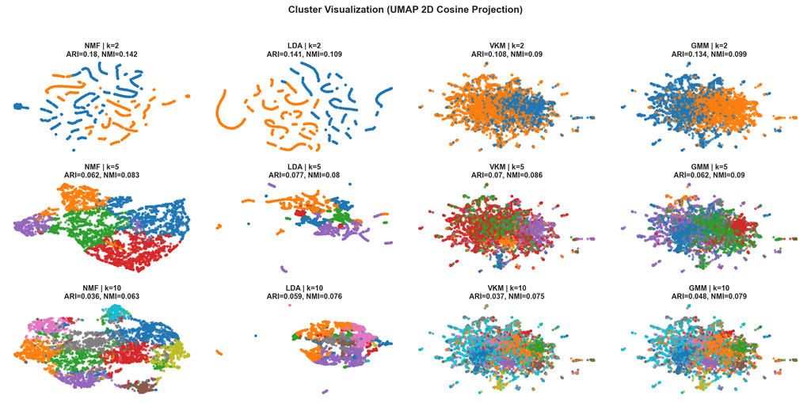

```python
cluster_charts(ml_dct=dct_models,models=test_models,umap_metric ='cosine')
```

Above is the chart which shows the clustering at k2, k5 and k10. This is shown for all our four models. While it may be hard to interpret, intuitively we see that the two models on the left seem to seperate the clusters better. The other two models, GMM and VKM look way more chaotic, the different clusters are all overlapping. Along with the visual overview there is also a score for ARI and NMI which can be interpreted as higher equals better. Lower scores on these measures can mean that the model is bad or that the k is unsuitable. We believe poor performance across the 3 shown k’s are a pretty good indication of general performance.

### plot_ic

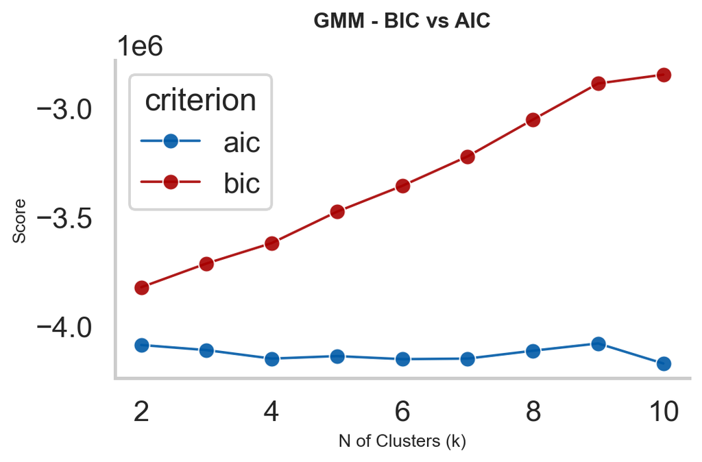

```python
plot_ic(comparisons)
```

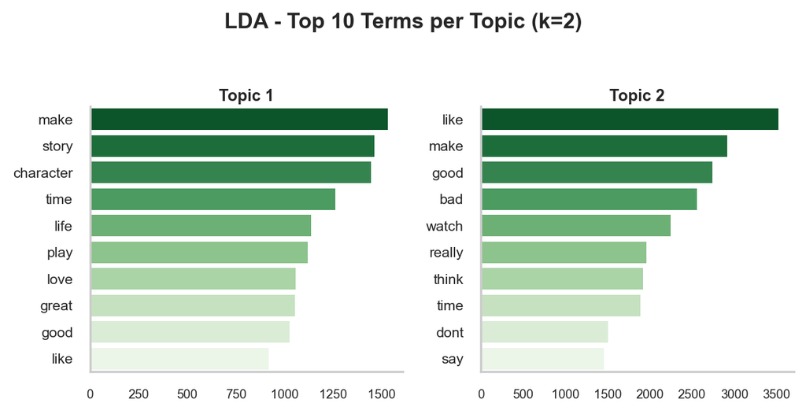

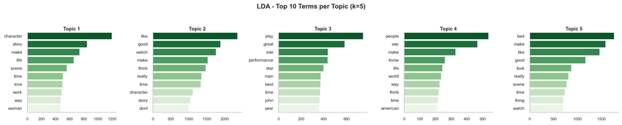

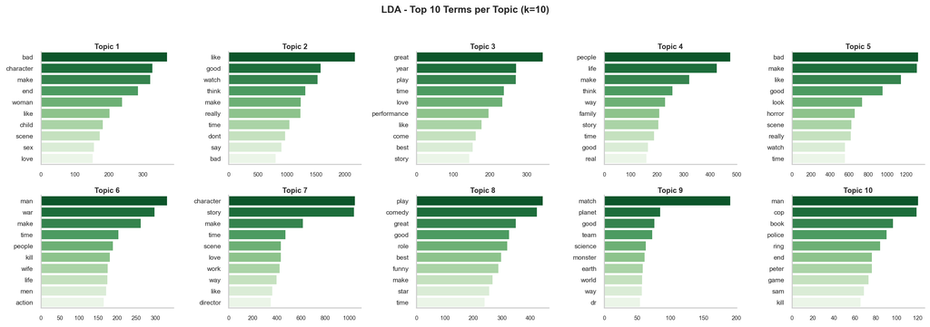

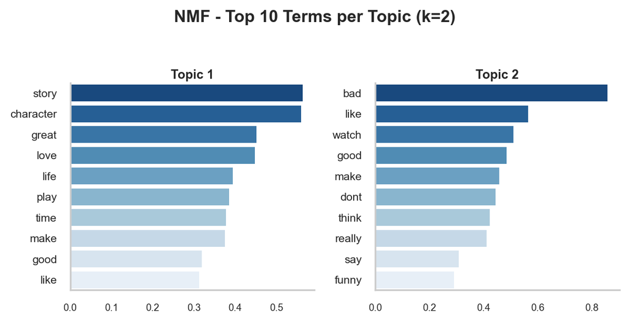

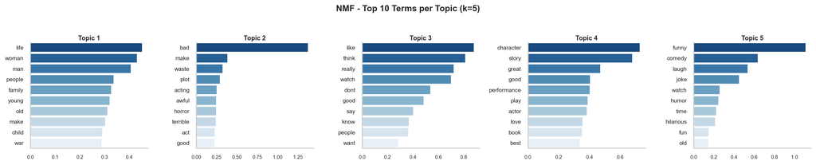

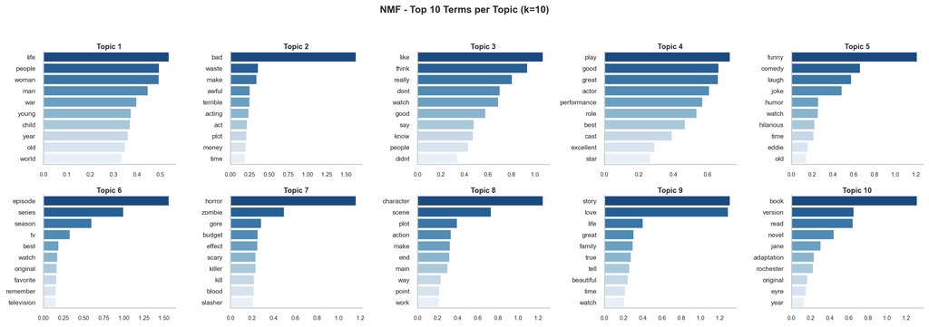

```python
plot_top_terms(cleaned,dct_models)
```

This plot shows the top 10 terms for each topic that was used to form a cluster across k2, k5 and k10 for the models that use topic modelling. These plots make the algorithm a lot more intuitive for us to look at, we can see what words the model decided to put together to form a cluster. While we can not measure the words with a number like the previous plot, we can interpret the meaning of the words to see if we agree with the grouping. An example of a group which went well is topic 7 for the nmf model in k10. We can see words like: horror, zombie, gore and scary. To us this makes a lot of sense and gives us confidence in the clustering that was made by this model in this specific k.

### plot_sentiment_cluster_panel

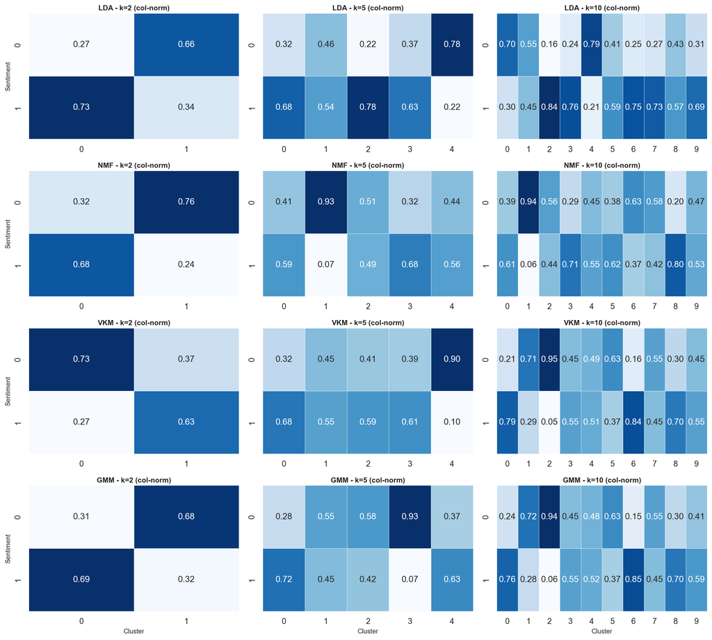

```python
plot_sentiment_cluster_panel(dct_models, normalize="col")
```

# Team member contributions

Write down what each team member contributed to the project.

- Leonardo Savianne: Data preparation, made the code for the models and the graphs in the results.
- Thomas Rietman: Wrote the story, explained the models interpreted the results, cleanup and putting it all together.
- Angelos Papoutsis: Review

# GitHub Repo

In our [Github repo](https://github.com/LeonSavi/ADS-DW4) you can find more materials, such as: charts, csv with data, R codes, codes contribution.

# References

Our reading material we used for this assignment:

- Text Cleaning in Python: https://www.geeksforgeeks.org/machine-learning/text-preprocessing-in-python-set-1/
- Wordnet fix: https://stackoverflow.com/questions/15586721/wordnet-lemmatization-and-pos-tagging-in-python
- Count Vectorizer and TFIDF: https://medium.com/@ashwinkumar577/countvectorizer-and-tfidfvectorizer-for-beginner-ac81afef30aa
- NMF: https://medium.com/codex/what-is-non-negative-matrix-factorization-nmf-32663fb4d65
- TF-IDF: https://www.geeksforgeeks.org/machine-learning/understanding-tf-idf-term-frequency-inverse-document-frequency/
- SVD vs PCA: https://www.youtube.com/watch?v=AA9yjhj0cnE&t=116
- SVD vs PCA2: https://www.youtube.com/watch?v=5HNr_j6LmPc
- Why LDA should not use IDFDF inputs: https://stackoverflow.com/a/44789327/6470915
- LDA w/ TFIDF: https://medium.com/analytics-vidhya/topic-modelling-using-word-embeddings-and-latent-dirichlet-allocation-3494778307bc
- TruncatedSVD: https://www.youtube.com/watch?v=gVLIk43B5_U
- UMAP: https://pair-code.github.io/understanding-umap/
- BIC & AIC: https://medium.com/@jshaik2452/choosing-the-best-model-a-friendly-guide-to-aic-and-bic-af220b33255f
- V-Measure: https://www.geeksforgeeks.org/machine-learning/ml-v-measure-for-evaluating-clustering-performance/
- Other Scores: https://medium.com/@Sunil_Kumawat/performance-metrics-for-clustering-9badee0b7db8
- Cosine: https://www.geeksforgeeks.org/dbms/cosine-similarity/